# Alcoholic beverages-tobacco

library(forecast) library(tseries)

## 1.Introduction

This R script aims to forecast the consumer price index for alcohol and tobacco products by using survey data and interest rates.The survey includes questions about consumer expectations about future price increases.

## 2.Figures

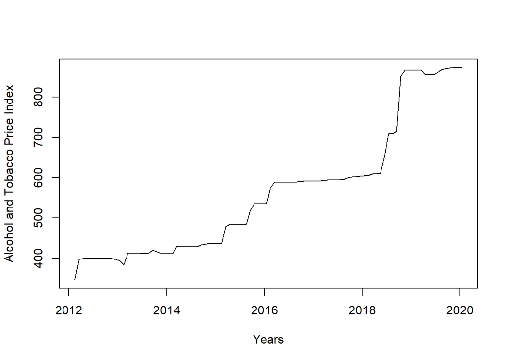

```r
plot(tsAlkoltutun, ylab=c("Alcohol and Tobacco Price Index"), xlab=c("Years"))
```

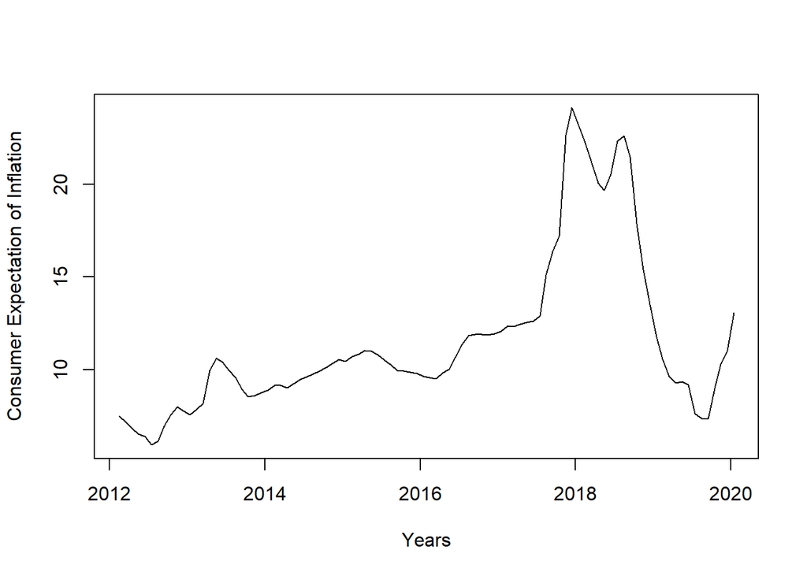

```r
plot(tsBeklenti, ylab=c("Consumer Expectation of Inflation"), xlab=c("Years"))
```

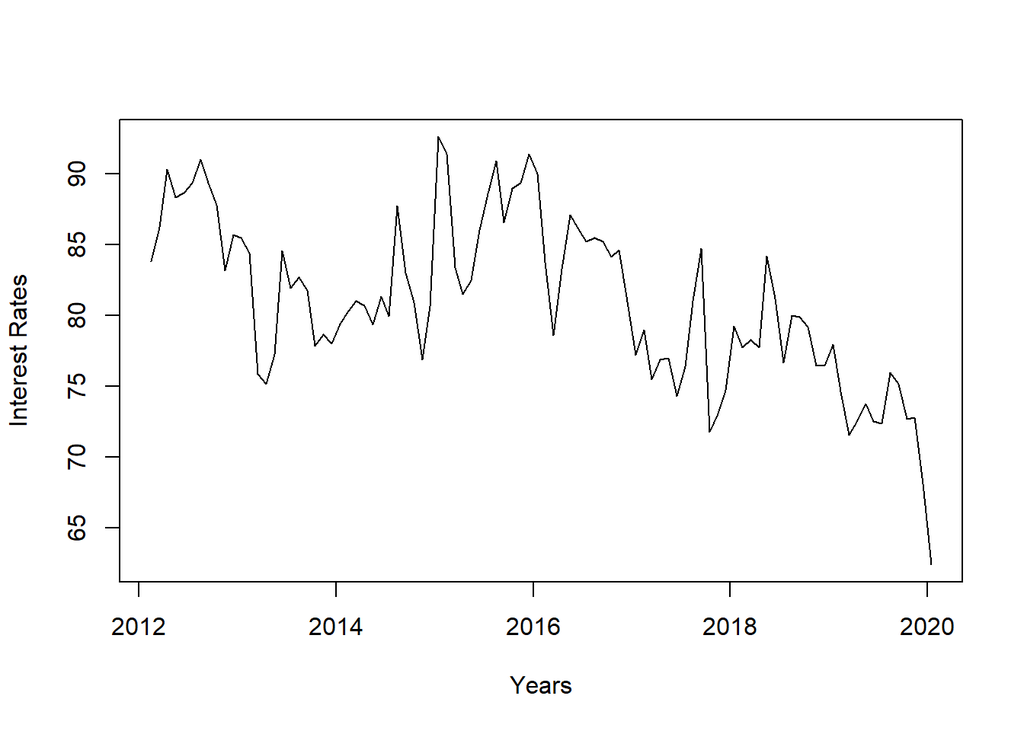

[figure not shown]

```r
plot(tsFaiz, ylab=c("Interest Rates"), xlab=c("Years"))
```

## 3.Appendix

Alkoltutun<-c(347.38, 396.91, 400.20, 400.18, 400.16, 400.17, 400.14, 399.80, 399.86, 399.92, 396.99, 394.43, 383.94, 412.55, 412.65, 412.57, 412.67, 412.05, 411.81, 420.02, 418.09, 413.42, 413.41, 413.42, 413.37, 430.69, 428.79, 428.76, 428.83, 428.86, 428.83, 433.80, 435.34, 436.87, 436.83, 436.85, 436.87, 478.81, 483.58, 483.59, 483.88, 483.73, 483.72, 517.80, 535.59, 535.63, 535.60, 535.64, 574.89, 588.45, 588.60, 588.59, 588.65, 588.66, 588.70, 591.00, 591.27, 591.32, 591.32, 591.40, 591.36, 593.67, 593.86, 593.87, 593.92, 594.83, 594.96, 599.46, 602.00, 602.41, 603.51, 604.56, 605.52, 609.26, 609.94, 609.99, 651.31, 709.14, 709.43, 714.76, 851.35, 866.61, 866.63, 866.66, 866.65, 866.45, 854.81, 855.12, 855.31, 860.99, 868.44, 870.40, 872.12, 872.47, 872.40, 872.43)

Beklenti <-c(7.51, 7.17, 6.87, 6.55, 6.41, 5.95, 6.14, 6.95, 7.56, 7.99, 7.78, 7.58, 7.87, 8.20, 9.98, 10.62, 10.43, 9.96, 9.58, 8.92, 8.53, 8.60, 8.76, 8.91, 9.15, 9.15, 9.03, 9.26, 9.49, 9.62, 9.78, 9.94, 10.11, 10.34, 10.56, 10.45, 10.70, 10.85, 11.02, 11.01, 10.81, 10.50, 10.25, 9.95, 9.93, 9.88, 9.79, 9.65, 9.57, 9.50, 9.84, 10.04, 10.68, 11.34, 11.84, 11.89, 11.92, 11.88, 11.94, 12.07, 12.36, 12.31, 12.44, 12.55, 12.63, 12.92, 15.09, 16.37, 17.22, 22.63, 24.11, 23.17, 22.25, 21.15, 20.04, 19.65, 20.54, 22.30, 22.62, 21.47, 17.88, 15.39, 13.51, 11.78, 10.57, 9.64, 9.29, 9.36, 9.19, 7.65, 7.38, 7.34, 8.98, 10.29, 11.04, 13.08)

Faiz <-c(83.83, 86.23, 90.31, 88.30, 88.62, 89.36, 91.00, 89.33, 87.76, 83.17, 85.67, 85.47, 84.41, 75.87, 75.14, 77.24, 84.56, 81.94, 82.70, 81.75, 77.84, 78.65, 77.99, 79.38, 80.34, 81.00, 80.69, 79.36, 81.36, 79.93, 87.71, 83.01, 80.93, 76.87, 80.64, 92.60, 91.36, 83.40, 81.52, 82.46, 85.99, 88.61, 90.92, 86.57, 88.99, 89.36, 91.41, 90.00, 83.74, 78.62, 83.27, 87.07, 86.16, 85.20, 85.47, 85.20, 84.13, 84.64, 80.95, 77.18, 78.98, 75.46, 76.90, 77.01, 74.29, 76.38, 81.04, 84.71, 71.75, 73.05, 74.73, 79.26, 77.72, 78.29, 77.76, 84.21, 81.20, 76.68, 79.99, 79.86, 79.19, 76.43, 76.45, 77.94, 74.63, 71.54, 72.56, 73.76, 72.50, 72.36, 75.98, 75.13, 72.71, 72.78, 68.13, 62.41)

tsBeklenti <-ts(data=Beklenti,start=c(2012.12), frequency=12)

tsAlkoltutun <-ts(data=Alkoltutun, start=c(2012.12), frequency=12)

tsFaiz <-ts(data=Faiz, start=c(2012.12), frequency=12)

Matrixrex <-cbind(tsBeklenti,tsFaiz)

Model1 <-auto.arima(tsAlkoltutun, xreg=Matrixrex, stationary=c(“false”))

forecast1 <-forecast(Model1,xreg=Matrixrex)